# Some practical computational aspects of non-parametric (distributional) regression

## Not flexible enough - beyond the mean

(I stole the title of the subsection from Thomas Kneib’s [excellent paper](https://journals.sagepub.com/doi/10.1177/1471082X13494159)).

Sometimes we find that it is not only the mean of our data that varies, but other properties at well. In the precipitation record we just analysed for example in the summer months we observe higher means and higher variability. Since the Gamma is already modeled taking $Var(Y) = \phi \mu$ we might think that we would capture this feature of the data in out model, but we can actually notice that the coefficient of variation is lower in the summer months. The increase in precipitation comes with a smaller increase in variation that the one seen in the winter months, while no clear signal is noticeable in the year to year signal:

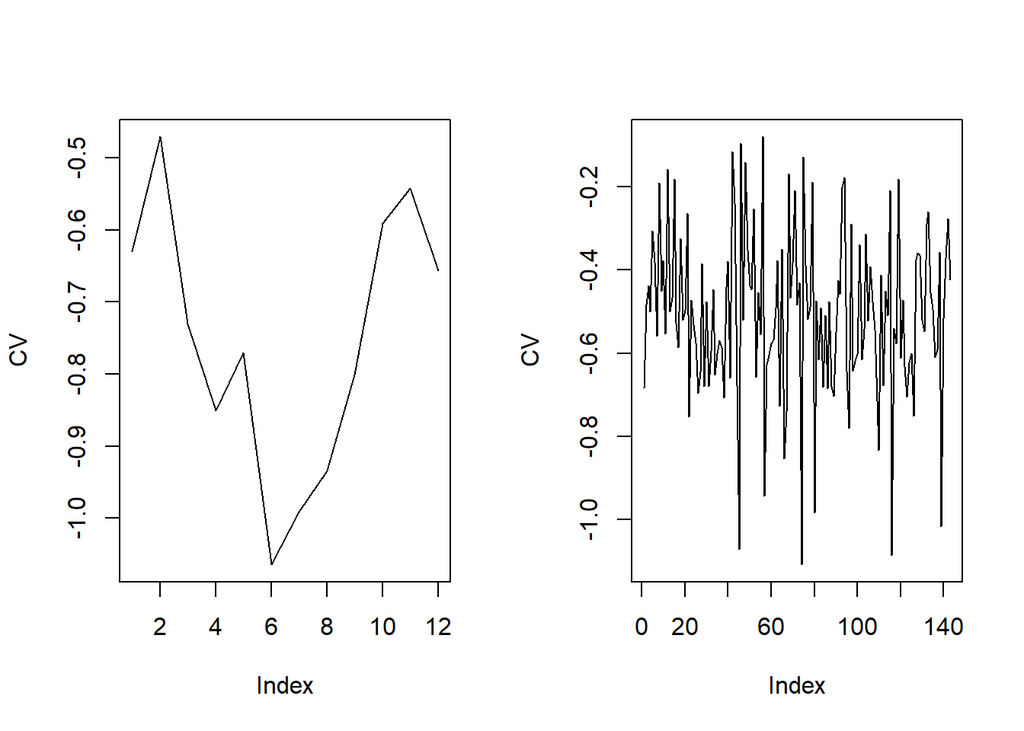

```r
par(mfrow=c(1,2))
plot(tapply(subclim$Precip,subclim$month,function(x) log(sd(x) / mean(x))), type="l", ylab = "CV")
plot(tapply(subclim$Precip,subclim$year,function(x) log(sd(x) / mean(x))), type="l", ylab = "CV")
```

We can then ask `mgcv` to also model the *scale* of the distribution:

```r
fitls_precip <- gam(list(
                         Precip ~ s(year, k=20)+s(month, k = 12), # a model for the mean
                         ~ s(year, k=20)+s(month, k = 12)), # a model for the scale
                    family = gammals, data = subclim, method = "REML", optimizer = "efs")
summary(fitls_precip)
```

```
##
## Family: gammals
## Link function: identity log
##
## Formula:
## Precip ~ s(year, k = 20) + s(month, k = 12)
## ~s(year, k = 20) + s(month, k = 12)
##
## Parametric coefficients:
##               Estimate Std. Error z value Pr(>|z|)
## (Intercept)    1.04898    0.01211   86.62   <2e-16 ***
## (Intercept).1  5.56480    0.03302  168.54   <2e-16 ***
## ---
## Signif. codes:  0 '***' 0.001 '**' 0.01 '*' 0.05 '.' 0.1 ' ' 1
##
## Approximate significance of smooth terms:
##              edf Ref.df   Chi.sq  p-value
## s(year)    1.959  2.448   19.844 0.000147 ***
## s(month)   8.415  9.800 1248.131  < 2e-16 ***
## s.1(year)  1.010  1.020    0.003 0.986536
## s.1(month) 6.076  7.437   99.251  < 2e-16 ***
## ---
## Signif. codes:  0 '***' 0.001 '**' 0.01 '*' 0.05 '.' 0.1 ' ' 1
##
## Deviance explained = 42.6%
## -REML = 2894.9  Scale est. = 1         n = 1716
```

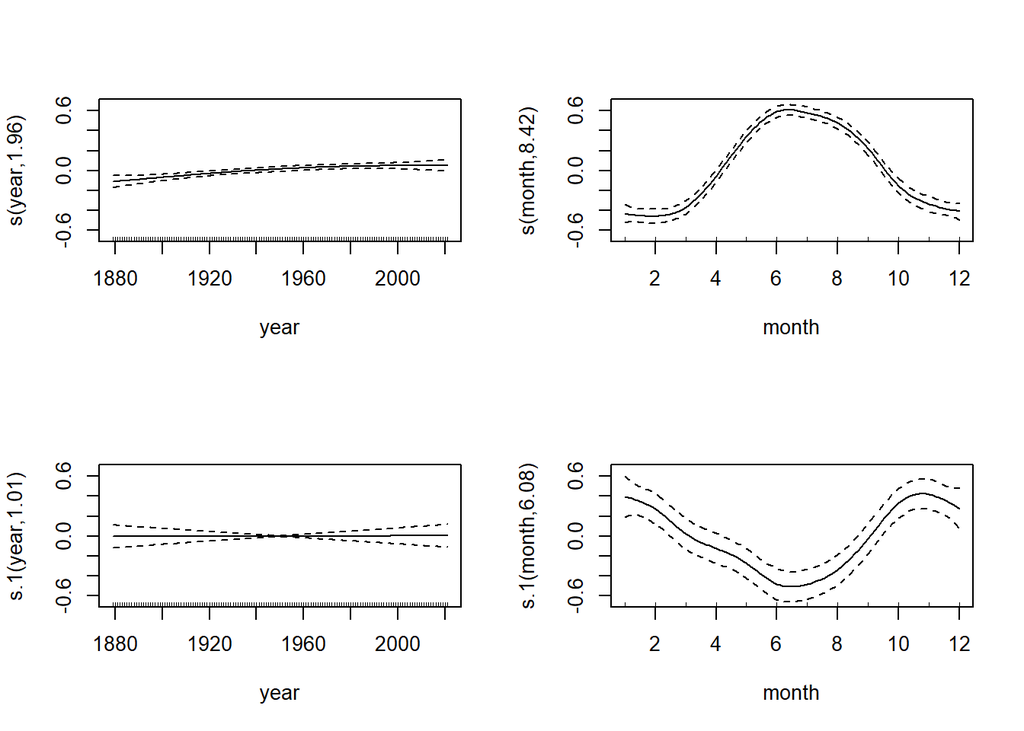

```r
plot(fitls_precip, page = 1)
```

(notice that `gammals` uses the identity link for the log-location, rather than the inverse used by `Gamma`)

We see that the scale appears to be changing with month, but no effect is found for `year`, we can change our model accordingly:

```r
fitls_precip <- gam(list(
                         Precip ~ s(year, k=20)+s(month, k = 12), # a model for the mean
                         ~ s(month, k = 12)), # a model for the scale
                    family = gammals, data = subclim, method = "REML", optimizer = "efs")
summary(fitls_precip)
```

```
##
## Family: gammals
## Link function: identity log
##
## Formula:
## Precip ~ s(year, k = 20) + s(month, k = 12)
## ~s(month, k = 12)
##
## Parametric coefficients:
##               Estimate Std. Error z value Pr(>|z|)
## (Intercept)    1.04899    0.01211   86.63   <2e-16 ***
## (Intercept).1  5.56482    0.03302  168.54   <2e-16 ***
## ---
## Signif. codes:  0 '***' 0.001 '**' 0.01 '*' 0.05 '.' 0.1 ' ' 1
##
## Approximate significance of smooth terms:
##              edf Ref.df  Chi.sq  p-value
## s(year)    1.946  2.433   19.80 0.000146 ***
## s(month)   8.418  9.802 1251.46  < 2e-16 ***
## s.1(month) 6.075  7.436   99.41  < 2e-16 ***
## ---
## Signif. codes:  0 '***' 0.001 '**' 0.01 '*' 0.05 '.' 0.1 ' ' 1
##
## Deviance explained = 42.6%
## -REML = 2892.5  Scale est. = 1         n = 1716
```

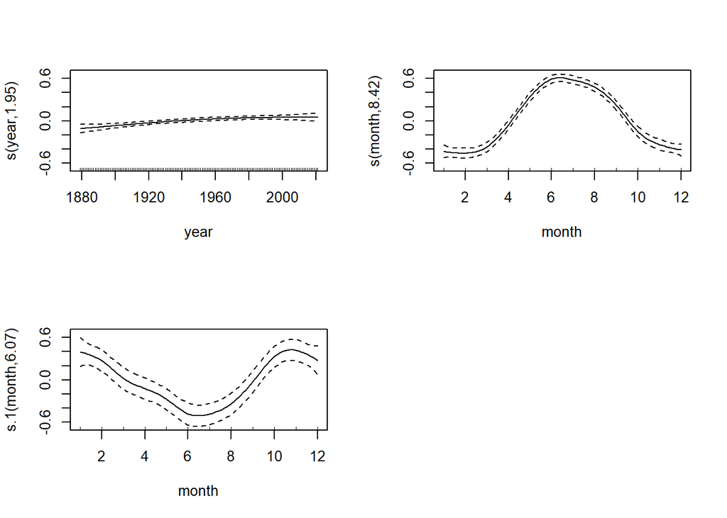

```r
plot(fitls_precip, page = 1)
```

We can plot the fitted location ans scale (only the first 40 years to avoid clogging the figure):

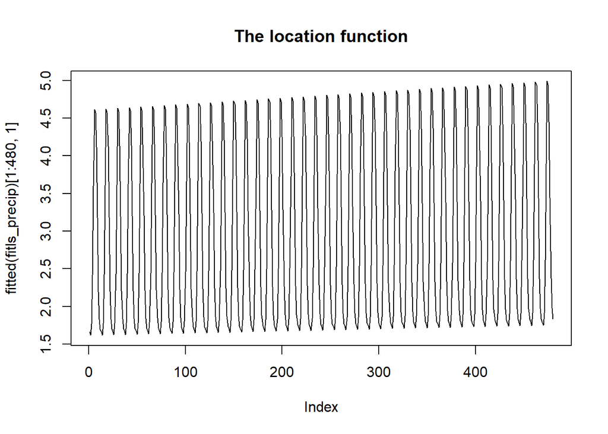

```r
plot(fitted(fitls_precip)[1:480,1], type="l", main = "The location function")
```

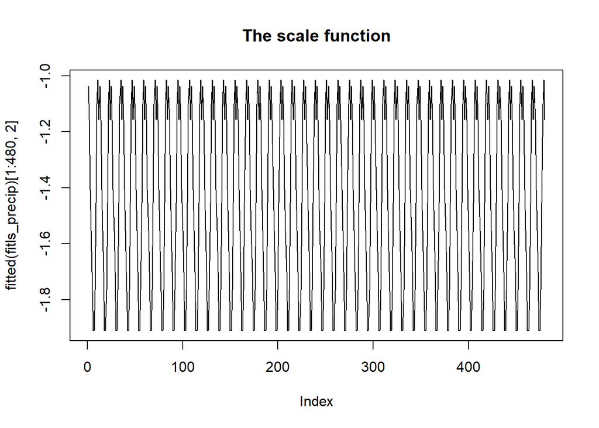

```r
plot(fitted(fitls_precip)[1:480,2], type="l", main = "The scale function")
```

(Notice that the scale function is on a non-intuitive scale, i.e. the log of the actual scale)

`mgcv` does not provide much flexibility in terms of link functions and specific choices of modelling strategies for the scale parameters. Indeed the location-scale models are a fairly recent addition to `mgcv`, as they are computationally quite challenging, especially when one also wishes to automatically (automagically?) estimate the smoothing parameter for all model components of several distribution parameters. Therefore the number of location-scale-shape models which are already implemented in `mgcv` is somewhat limited (although it is not too complicated to add new distributions if one wishes to exploit the package’s capabilities).

Indeed, with all their flexibility, GAMs are still actually quite restrictive in terms of the distributions that can be employed as the response and in terms of which properties of the distributions can be modeled: to overcome these restrictions some further generalizations have been proposed. In particular we can extend GL/AMs by relaxing the assumption that the distribution of the response variable should belong to the exponential family of distributions, but simply assume that it belongs to a distribution $\mathcal{D}(y, \boldsymbol{\theta})$, where $\boldsymbol{\theta}$ can be a multivariate vector, for example $\boldsymbol{\theta} = (\mu, \sigma, \nu, \tau)$, where the latter two parameters are shape parameters which might be useful to describe the skewness and kurtosis of a distribution. For several commonly employed distributions, such as those belonging to the exponential family, the skewness and kurtosis are fully determined by the location and scale, but in several application we might wish to have more flexibility to describe the peculiar behavior of the data and would need to also include additional parameters. Furthermore, extending the concepts related to generalized additive models we can assume that each of the parameters indexing the distributions might vary as a smooth function of one or more predictors.

Summarizing we assume that, conditional on the covariates vector $\boldsymbol{x_i} =(x_{1i}, \ldots , x_{pi})$, the observations $y_i$ are assumed to be independent realizations of a random variable $Y_i$ which follows a distribution $\mathcal D$ indexed by $K$ parameters: $(Y_i|\boldsymbol{X_i} =\boldsymbol{x_i}) \sim \mathcal D(\theta_{1i}, \ldots, \theta_{Ki})$. Each distribution parameter is assumed to be related to a linear predictor $\eta_i^{\theta_k}$ which is taken to be of the form:
$$\begin{equation}
\eta_i^{\theta_{k}} = g(\theta_{ki}) = \beta_0^{\theta_{k}} +
f_1^{\theta_{k}}(x_{1i}) + \ldots + f_p^{\theta_k}(x_{pi})
\end{equation}$$
where the $f^{\theta_{k}}_j(x_{ji})$ components might represent parametric or unknown functions of the covariates which might be represented by penalized regression. Notice that a suitable link function needs to be chosen for each parameter and that there is no restriction that the same covariates need to be employed as predictors for the different parameters.

### `gamlss`

We briefly show how to use the `gamlss` package to fit a model for location, scale and shape. We start with the same model for the precipitation data based on the location and scale of a Gamma distribution:

```r
library(gamlss)
fitgamlss_precip <- gamlss(Precip ~ pb(year)+pb(month), # a model for the mean
                           sigma.formula = ~ pb(month), # a model for the scale
                     family = GA, data = subclim[,c("month","year","Precip")])
```

```
## GAMLSS-RS iteration 1: Global Deviance = 5706.077
## GAMLSS-RS iteration 2: Global Deviance = 5706.022
## GAMLSS-RS iteration 3: Global Deviance = 5706.032
## GAMLSS-RS iteration 4: Global Deviance = 5706.032
```

```r
summary(fitgamlss_precip)
```

```
## Family:  c("GA", "Gamma")
##
## Call:
## gamlss(formula = Precip ~ pb(year) + pb(month), sigma.formula = ~pb(month),
##     family = GA, data = subclim[, c("month", "year", "Precip")])
##
## Fitting method: RS()
##
## ------------------------------------------------------------------
## Mu link function:  log
## Mu Coefficients:
##               Estimate Std. Error t value Pr(>|t|)
## (Intercept) -1.3269591  0.5453034  -2.433   0.0151 *
## pb(year)     0.0011648  0.0002793   4.171 3.19e-05 ***
## pb(month)    0.0160397  0.0038481   4.168 3.22e-05 ***
## ---
## Signif. codes:  0 '***' 0.001 '**' 0.01 '*' 0.05 '.' 0.1 ' ' 1
##
## ------------------------------------------------------------------
## Sigma link function:  log
## Sigma Coefficients:
##              Estimate Std. Error t value Pr(>|t|)
## (Intercept) -0.740021   0.034768 -21.285   <2e-16 ***
## pb(month)    0.004169   0.004710   0.885    0.376
## ---
## Signif. codes:  0 '***' 0.001 '**' 0.01 '*' 0.05 '.' 0.1 ' ' 1
##
## ------------------------------------------------------------------
## NOTE: Additive smoothing terms exist in the formulas:
##  i) Std. Error for smoothers are for the linear effect only.
## ii) Std. Error for the linear terms may not be reliable.
## ------------------------------------------------------------------
## No. of observations in the fit:  1716
## Degrees of Freedom for the fit:  16.62795
##       Residual Deg. of Freedom:  1699.372
##                       at cycle:  4
##
## Global Deviance:     5706.032
##             AIC:     5739.288
##             SBC:     5829.873
```

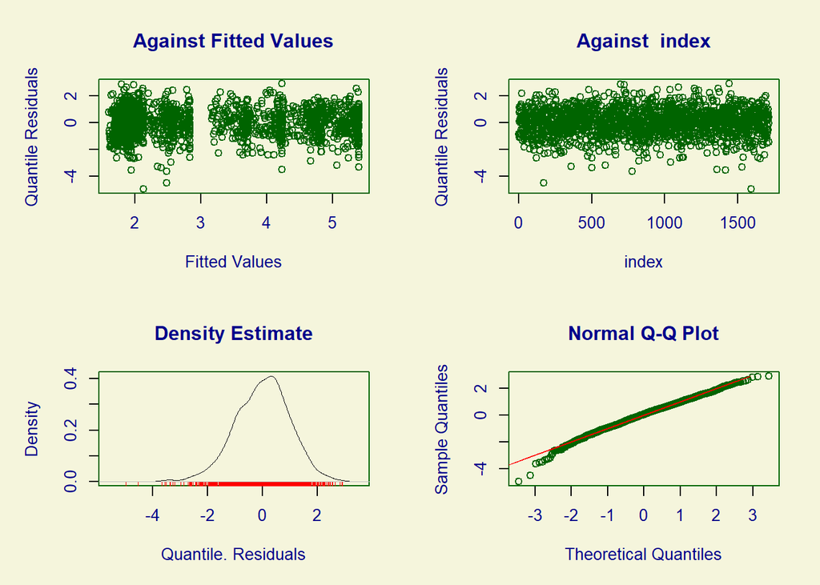

```
##        Summary of the Quantile Residuals
##                            mean   =  0.002113939
##                        variance   =  1.001379
##                coef. of skewness  =  -0.3481241
##                coef. of kurtosis  =  3.69409
## Filliben correlation coefficient  =  0.9960416
```

```r
plot(fitgamlss_precip) # a different default for what to plot
```

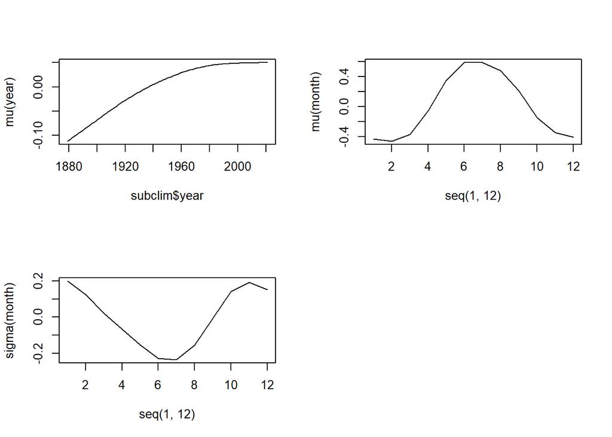

```r
# similar effects to what mgcv found
# to plot the terms we need to use predict/predcitAll
par(mfrow=c(2,2))
pout <- predictAll(fitgamlss_precip, type = "terms")
plot(subclim$year, pout$mu[,1], type="l",ylab="mu(year)")
plot(seq(1,12), pout$mu[1:12,2], type="l",ylab="mu(month)")
plot(seq(1,12), pout$sigma[1:12,1], type="l",ylab="sigma(month)")
```

The recommended smoother in `gamlss` is `pb`, which automatically selects the smoothing parameter and build upon P-splines. Other basis functions can also be used, including structured ones such as, for example, random effects or gaussian markov random fields.

We notice that the model residuals are somewhat left-skewed and have higher kurtosis than a normal distribution. Ideally quantile residuals should behave gaussian-like, so it is possible that the distribution we are using is too restrictive for our data, we can explore whether a three- or four-parameter distribution leads to a better fit in the data. Furthermore, by adding an additional shape parameter we can assess whether this changes as a function of some covariate: for example we could assess whether there is evidence that the skewness of the distribution is changing in time as a result of the impacts of climate change. As a first step we employ a more flexible distribution which has additional skewness and kurtosis parameters and then assess whether these are changing as a function of covariates. The `gamlss.dist` package implements a large number of distributions, we explore here the BCCG distribution which is parametrized by three parameters and can capture additional skewness in the distribution:

```r
fitgamlss2_precip <- gamlss(Precip ~ pb(year)+pb(month), # a model for the mean
                            sigma.formula = ~ pb(month), # a model for the scale
                            nu.formula = ~ 1,            # no model for shape yet
                     family = BCCG(), data = subclim[,c("month","year","Precip","TMean")])
```

```
## GAMLSS-RS iteration 1: Global Deviance = 5741.479
## GAMLSS-RS iteration 2: Global Deviance = 5657.197
## GAMLSS-RS iteration 3: Global Deviance = 5655.369
## GAMLSS-RS iteration 4: Global Deviance = 5655.174
## GAMLSS-RS iteration 5: Global Deviance = 5655.141
## GAMLSS-RS iteration 6: Global Deviance = 5655.135
## GAMLSS-RS iteration 7: Global Deviance = 5655.133
## GAMLSS-RS iteration 8: Global Deviance = 5655.133
```

```r
summary(fitgamlss2_precip)
```

```
## Family:  c("BCCG", "Box-Cox-Cole-Green")
##
## Call:
## gamlss(formula = Precip ~ pb(year) + pb(month), sigma.formula = ~pb(month),
##     nu.formula = ~1, family = BCCG(), data = subclim[, c("month",
##         "year", "Precip", "TMean")])
##
## Fitting method: RS()
##
## ------------------------------------------------------------------
## Mu link function:  identity
## Mu Coefficients:
##               Estimate Std. Error t value Pr(>|t|)
## (Intercept) -4.1603546  1.2569154  -3.310 0.000953 ***
## pb(year)     0.0032925  0.0006462   5.095 3.86e-07 ***
## pb(month)    0.0321045  0.0067772   4.737 2.35e-06 ***
## ---
## Signif. codes:  0 '***' 0.001 '**' 0.01 '*' 0.05 '.' 0.1 ' ' 1
##
## ------------------------------------------------------------------
## Sigma link function:  log
## Sigma Coefficients:
##              Estimate Std. Error t value Pr(>|t|)
## (Intercept) -0.413879   0.036393  -11.37   <2e-16 ***
## pb(month)   -0.073230   0.004945  -14.81   <2e-16 ***
## ---
## Signif. codes:  0 '***' 0.001 '**' 0.01 '*' 0.05 '.' 0.1 ' ' 1
##
## ------------------------------------------------------------------
## Nu link function:  identity
## Nu Coefficients:
##             Estimate Std. Error t value Pr(>|t|)
## (Intercept)  0.48756    0.03644   13.38   <2e-16 ***
## ---
## Signif. codes:  0 '***' 0.001 '**' 0.01 '*' 0.05 '.' 0.1 ' ' 1
##
## ------------------------------------------------------------------
## NOTE: Additive smoothing terms exist in the formulas:
##  i) Std. Error for smoothers are for the linear effect only.
## ii) Std. Error for the linear terms may not be reliable.
## ------------------------------------------------------------------
## No. of observations in the fit:  1716
## Degrees of Freedom for the fit:  24.51065
##       Residual Deg. of Freedom:  1691.489
##                       at cycle:  8
##
## Global Deviance:     5655.133
##             AIC:     5704.154
##             SBC:     5837.682
```

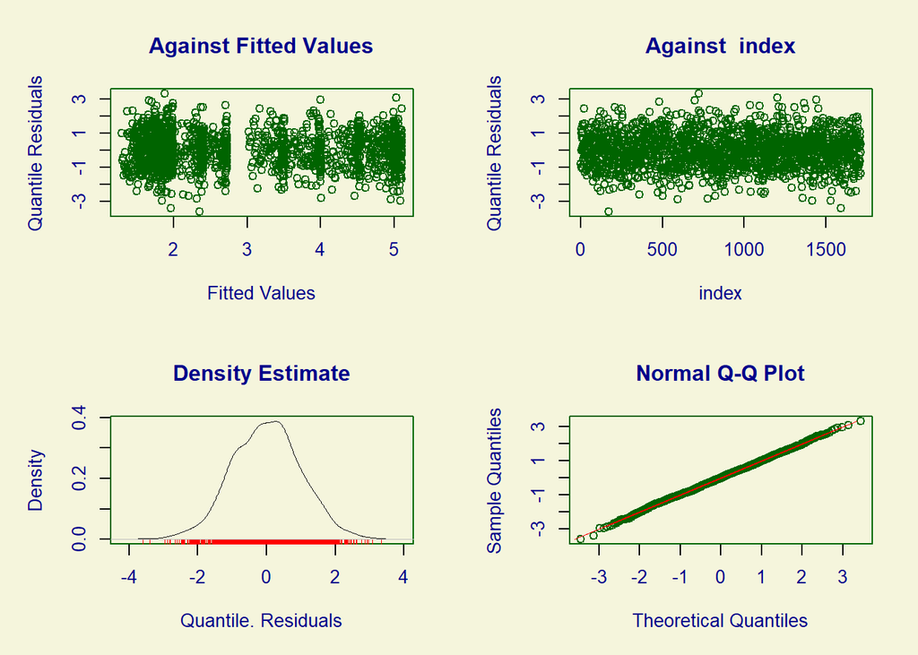

```
##        Summary of the Quantile Residuals
##                            mean   =  0.000809619
##                        variance   =  1.000723
##                coef. of skewness  =  -0.006349872
##                coef. of kurtosis  =  3.048639
## Filliben correlation coefficient  =  0.9996975
```

```r
plot(fitgamlss2_precip) #  residuals a bit better behaved
```

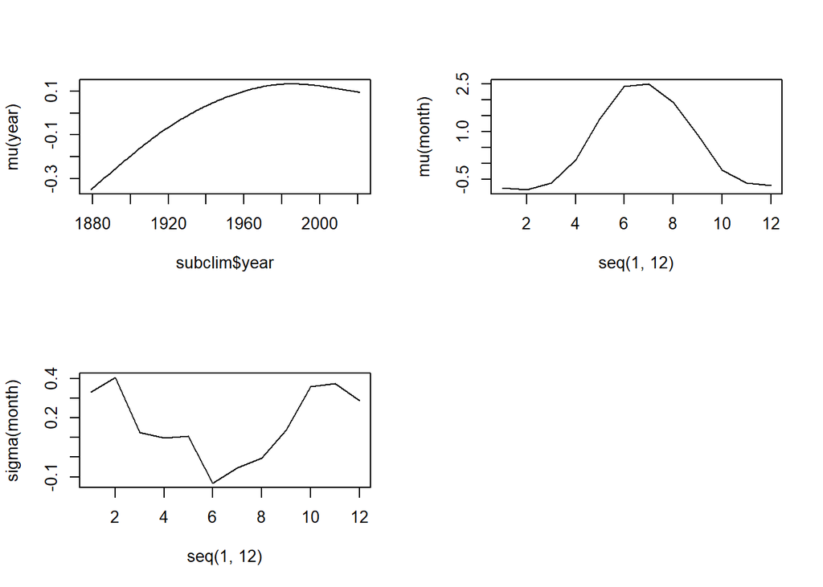

```r
# to plot the terms we need to use predict/predcitAll
par(mfrow=c(2,2))
pout <- predictAll(fitgamlss2_precip, type = "terms")
plot(subclim$year, pout$mu[,1], type="l",ylab="mu(year)")
plot(seq(1,12), pout$mu[1:12,2], type="l",ylab="mu(month)")
plot(seq(1,12), pout$sigma[1:12,1], type="l",ylab="sigma(month)")
```

We see that the additional parameter captures the additional skewness. We could indeed assess whether the shape of the distribution also changes a function of some covariate.

```r
fitgamlss3_precip <- gamlss(Precip ~ pb(year)+pb(month), # a model for the mean
                            sigma.formula = ~ pb(month), # a model for the scale
                            nu.formula = ~ pb(year),     # is the skewness of the distribution changing?
                     family = BCCG(), data = subclim[,c("month","year","Precip")])
```

```
## GAMLSS-RS iteration 1: Global Deviance = 5737.431
## GAMLSS-RS iteration 2: Global Deviance = 5650.931
## GAMLSS-RS iteration 3: Global Deviance = 5648.996
## GAMLSS-RS iteration 4: Global Deviance = 5648.714
## GAMLSS-RS iteration 5: Global Deviance = 5648.674
## GAMLSS-RS iteration 6: Global Deviance = 5648.67
## GAMLSS-RS iteration 7: Global Deviance = 5648.671
```

```r
summary(fitgamlss3_precip)
```

```
## Family:  c("BCCG", "Box-Cox-Cole-Green")
##
## Call:
## gamlss(formula = Precip ~ pb(year) + pb(month), sigma.formula = ~pb(month),
##     nu.formula = ~pb(year), family = BCCG(), data = subclim[,
##         c("month", "year", "Precip")])
##
## Fitting method: RS()
##
## ------------------------------------------------------------------
## Mu link function:  identity
## Mu Coefficients:
##               Estimate Std. Error t value Pr(>|t|)
## (Intercept) -4.2667326  1.2417646  -3.436 0.000604 ***
## pb(year)     0.0033489  0.0006382   5.247 1.74e-07 ***
## pb(month)    0.0314502  0.0067473   4.661 3.39e-06 ***
## ---
## Signif. codes:  0 '***' 0.001 '**' 0.01 '*' 0.05 '.' 0.1 ' ' 1
##
## ------------------------------------------------------------------
## Sigma link function:  log
## Sigma Coefficients:
##              Estimate Std. Error t value Pr(>|t|)
## (Intercept) -0.431742   0.036393  -11.86   <2e-16 ***
## pb(month)   -0.069408   0.004945  -14.04   <2e-16 ***
## ---
## Signif. codes:  0 '***' 0.001 '**' 0.01 '*' 0.05 '.' 0.1 ' ' 1
##
## ------------------------------------------------------------------
## Nu link function:  identity
## Nu Coefficients:
##               Estimate Std. Error t value Pr(>|t|)
## (Intercept) -0.7049540  1.7227745  -0.409    0.682
## pb(year)     0.0006109  0.0008833   0.692    0.489
##
## ------------------------------------------------------------------
## NOTE: Additive smoothing terms exist in the formulas:
##  i) Std. Error for smoothers are for the linear effect only.
## ii) Std. Error for the linear terms may not be reliable.
## ------------------------------------------------------------------
## No. of observations in the fit:  1716
## Degrees of Freedom for the fit:  26.63832
##       Residual Deg. of Freedom:  1689.362
##                       at cycle:  7
##
## Global Deviance:     5648.671
##             AIC:     5701.947
##             SBC:     5847.066
```

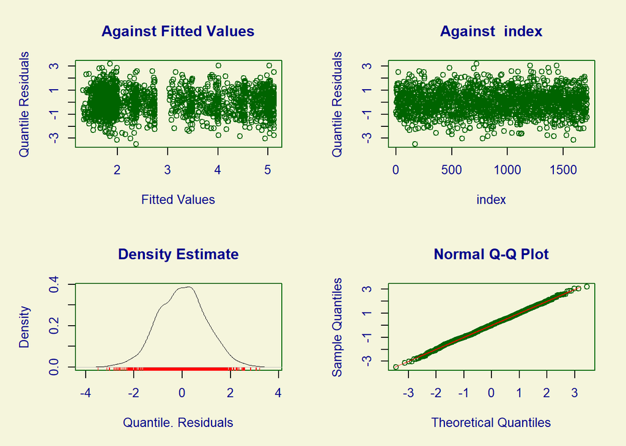

```
##        Summary of the Quantile Residuals
##                            mean   =  0.001756462
##                        variance   =  1.000695
##                coef. of skewness  =  -0.0120291
##                coef. of kurtosis  =  3.021343
## Filliben correlation coefficient  =  0.9996857
```

```r
plot(fitgamlss3_precip)
```

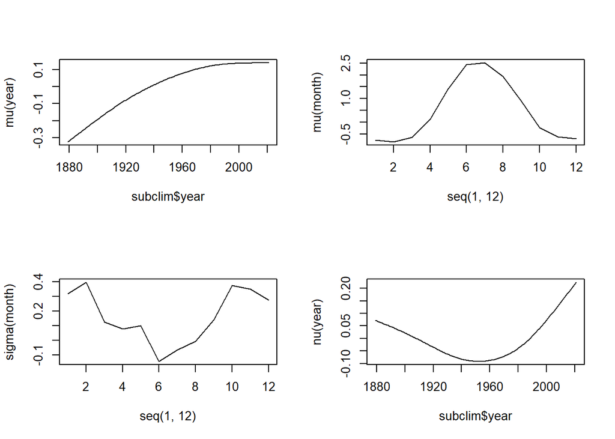

```r
# to plot the terms we need to use predict
# similar effects to what found before
par(mfrow=c(2,2))
pout <- predictAll(fitgamlss3_precip, type = "terms")
plot(subclim$year, pout$mu[,1], type="l",ylab="mu(year)")
plot(seq(1,12), pout$mu[1:12,2], type="l",ylab="mu(month)")
plot(seq(1,12), pout$sigma[1:12,1], type="l",ylab="sigma(month)")
plot(subclim$year, pout$nu, type="l",ylab="nu(year)")
```

Overall GAM(LSS) offer a great deal of flexibility in our modelling, this addiotional flexibility requires careful checks of the modelling assumptions which are not discussed here but should be part of a real data analysis. These are based on the same principles as in GLM

## Other approaches/material

As you might have noticed `mgcv` is very `base-R` oriented, but packages exist to make their manipulation more tidyverse compliant: `broom` has tidyers for `gam` objects and Gavin Simpson develops and maintains [`gratia`](https://gavinsimpson.github.io/gratia/), which provides functions to plot outputs of `gam` objects via ggplot (his [blog](https://gavinsimpson.github.io/gratia/) and papers are an excellent source of material on GAMs, mostly skewed on mgcv).

Rigby and Stasinopoulos (2005, 10.1111/j.1467-9876.2005.00510.x) introduced the concept of GAMLSS and develop and maintain the original `gamlss` package and [project](https://www.gamlss.com/). The package implements almost 100 distributions which can be employed as distributions for the response variable. A number of smoothers are implemented, and several strategies can be implemented for smoothing parameter selection.

The Rigby and Stasinopoulos approach is mostly frequentist, while a fully Bayesian approach to additive models for location scale and shape is taken by Umlauf et al. (2021, 10.18637/jss.v100.i04) in their `bamlss` package, which employs `mgcv` functions to construct the basis and penalty matrix and can fit all families implemented in `gamlss` and additional families included in `bamlss`. One of the interesting distributions implemented in `bamlss` is the Asymmetric Laplace distribution which allows for the smooth estimation of quantile regression.

Finally [`brms`](https://paul-buerkner.github.io/brms/) is a very general purpose package for Bayesian regression modelling via Stan - the package has a helpful [vignette](https://paul-buerkner.github.io/brms/articles/brms_distreg.html) introducing how `brms` implements distributional regression models. The `brms` implementation of smoothing is fully Bayesian and exploits the mixed model representation of penalized regression (TJ Mahr has a very clear dissection of this in his [blog post](https://www.tjmahr.com/random-effects-penalized-splines-same-thing/)).

The `VGAM` package, developed and maintained by T. Yee, further allows for multi-variate responses, a large number of smoothers and distributions.